# Reddit Nationalpark Data Exploration ¶

*▓▓▓▓▓▓▓ ▓▓▓▓▓▓▓, ▓▓▓▓▓▓▓, ▓▓▓▓▓▓▓ ▓▓▓▓▓▓▓ ▓▓▓▓▓▓▓; ▓▓▓▓▓▓▓ ▓▓▓▓▓▓▓, ▓▓▓▓▓▓▓ ▓▓▓▓▓▓▓ ▓▓▓▓▓▓▓, ▓▓▓▓▓▓▓*

* Redacted for double blind peer review

[figure not shown]

•••

Last updated: Aug-19-2023, [Carto-Lab Docker](https://gitlab.vgiscience.de/lbsn/tools/jupyterlab) Version 0.14.0

Visualization of temporal patterns for submissions and comments from Nationalpark-Subreddits.

# Preparations

```python
import os, sys
from pathlib import Path
import psycopg2
import geopandas as gp
import pandas as pd
import seaborn as sns
import calendar
import matplotlib
import matplotlib.pyplot as plt
import matplotlib.dates as mdates
import matplotlib.ticker as mticker
import matplotlib.patheffects as pe
from typing import List, Tuple, Dict, Optional
from IPython.display import clear_output, display, HTML
from datetime import datetime
```

```python
module_path = str(Path.cwd().parents[0] / "py")
if module_path not in sys.path:
    sys.path.append(module_path)
from modules.base import tools, hll
from modules.base.hll import union_hll, cardinality_hll
```

```python
%load_ext autoreload
%autoreload 2
```

```python
OUTPUT = Path.cwd().parents[0] / "out"       # output directory for figures (etc.)
WORK_DIR = Path.cwd().parents[0] / "tmp"     # Working directory
```

```python
(OUTPUT / "figures").mkdir(exist_ok=True)
(OUTPUT / "svg").mkdir(exist_ok=True)
WORK_DIR.mkdir(exist_ok=True)
```

Plot styling

```python
plt.style.use('default')
```

Set global font

```python
plt.rcParams['font.family'] = 'serif'
plt.rcParams['font.serif'] = ['Times New Roman'] + plt.rcParams['font.serif']
```

## Load HLL aggregate data

Load the data from CSV, generated in the previous notebook. Data is stored as aggregate HLL data (postcount, usercount) for each month.

```python
REDDIT_ALL_SUBMISSIONS = OUTPUT / "reddit_all_months.csv"
REDDIT_ALL_COMMENTS = OUTPUT / "reddit_comments_all_months.csv"
```

```python
%%time
data_files = {
    "REDDIT_ALL_SUBMISSIONS":REDDIT_ALL_SUBMISSIONS,
    "REDDIT_ALL_COMMENTS":REDDIT_ALL_COMMENTS,
    }
tools.display_file_stats(data_files)
```

| name | REDDIT_ALL_SUBMISSIONS | REDDIT_ALL_COMMENTS |
| --- | --- | --- |
| size | 428.49 KB | 1.16 MB |
| records | 2,448 | 2,221 |

```
CPU times: user 55 ms, sys: 5.33 ms, total: 60.3 ms
Wall time: 59.5 ms
```

```python
df = pd.read_csv(REDDIT_ALL_SUBMISSIONS)
```

```python
df.head(10)
```

|  | year | month | post_hll | user_hll | topic_group |
| --- | --- | --- | --- | --- | --- |
| 0 | 2010 | 10 | \x138b40c8a2 | \x138b40c303 | everglades |
| 1 | 2011 | 2 | \x138b40fd82 | \x138b40c303 | everglades |
| 2 | 2011 | 2 | \x138b40014238a147c16a8185618a648c83d3c1efc2 | \x138b4018214861750197a1c303dee1e021 | yosemite |
| 3 | 2011 | 3 | \x138b409481 | \x138b405e44 | yosemite |
| 4 | 2011 | 4 | \x138b4020c177c27be294a3 | \x138b4076a197a1c303 | yosemite |
| 5 | 2011 | 5 | \x138b4090e5c1e4 | \x138b404961c303 | grandcanyon |
| 6 | 2011 | 5 | \x138b4011815c826621a341bf81d505e1a2fc43 | \x138b4036c3c303 | hotsprings |
| 7 | 2011 | 5 | \x138b400d4212c19cc49e41ae64af41 | \x138b4003e21ac25e44c303dee1 | yosemite |
| 8 | 2011 | 6 | \x138b4004c316e42782286131013722488281e4b084c0... | \x138b4008a10f835e448062c303dca1e1a2ffa2 | yosemite |
| 9 | 2011 | 7 | \x138b403081 | \x138b405543 | hotsprings |

Get distinct subreddits:

```python
df['topic_group'].unique()
```

```
array(['everglades', 'yosemite', 'grandcanyon', 'hotsprings',
       'deathvalley', 'joshuatree', 'glaciernationalpark',
       'virginislands', 'bigbendtx', 'glacier', 'shenandoah',
       'deathvalleynp', 'americansamoa', 'bigbend', 'cuyahogafalls',
       'arches', 'craterlake', 'grandtetonnatlpark', 'northcascades',
       'isleroyale', 'gsmnp', 'pinnaclesnp', 'mount_rainier',
       'acadianationalpark', 'sequoia', 'kenaipeninsula', 'canyonlands',
       'brycecanyon', 'redwoodnationalpark', 'archesnationalpark',
       'bigbendnationalpark', 'zionnationalpark', 'capitolreefnp',
       'olympicnationalpark', 'lassenvolcanic', 'zionnp',
       'carlsbadcavernsnp', 'grandteton', 'rockymountain',
       'greatbasinstories', 'newrivergorgenp', 'shenandoahpark',
       'mammothcave', 'grandcanyonhiking'], dtype=object)
```

## Connect hll worker db

```python
DB_USER = "hlluser"
DB_PASS = os.getenv('READONLY_USER_PASSWORD')
# set connection variables
DB_HOST = "hllworkerdb"
DB_PORT = "5432"
DB_NAME = "hllworkerdb"
```

Connect to empty Postgres database running HLL Extension:

```python
DB_CONN = psycopg2.connect(
        host=DB_HOST,
        port=DB_PORT ,
        dbname=DB_NAME,
        user=DB_USER,
        password=DB_PASS
)
DB_CONN.set_session(
    readonly=True)
DB_CALC = tools.DbConn(
    DB_CONN)
CUR_HLL = DB_CONN.cursor()
```

```python
db_conn = tools.DbConn(DB_CONN)
```

test

```python
results = union_hll([df["post_hll"][0], df["post_hll"][1]], CUR_HLL)
results
```

```
'\\x138b40c8a2fd82'
```

```python
cardinality_hll(results, CUR_HLL)
```

```
2
```

# Calculate HLL Cardinality per month

Define additional functions for reading and formatting CSV as `pd.DataFrame`

```python
TIMESTAMP_FORMAT = '%Y %m'

def read_csv_datetime(csv: Path, timestamp_format: str = TIMESTAMP_FORMAT) -> pd.DataFrame:
    """Read CSV with parsing datetime index (months)

        First CSV column: Year
        Second CSV column: Month
    """
    date_cols = ["year", "month"]
    df = pd.read_csv(
        csv, index_col='datetime',
        parse_dates={'datetime':date_cols},
        date_format=timestamp_format,
        keep_date_col='False')
    df.drop(columns=date_cols, inplace=True)
    return df

def append_cardinality_df(df: pd.DataFrame, hll_col: str = "post_hll", cardinality_col: str = 'postcount_est'):
    """Calculate cardinality from HLL and append to extra column in df"""
    df[cardinality_col] = df.apply(
        lambda x: cardinality_hll(
           x[hll_col], CUR_HLL),
        axis=1)
    df.drop(columns=[hll_col], inplace=True)
    return df

def filter_fill_time(
        df: pd.DataFrame, min_year: int,
        max_year: int, val_col: str = "postcount_est",
        min_month: int = 1, max_month: int = 1):
    """Filter time values between min - max year and fill missing values"""
    min_date = pd.Timestamp(f'{min_year}-{min_month}-01')
    max_date = pd.Timestamp(f'{max_year}-{max_month}-01')
    # clip by start and end date
    if not min_date in df.index:
        df.loc[min_date, val_col] = 0
    if not max_date in df.index:
        df.loc[max_date, val_col] = 0
    df.sort_index(inplace=True)
    # mask min and max time
    time_mask = ((df.index >= min_date) & (df.index <= max_date))
    # fill missing months with 0
    # this will also set the day to max of month
    series = df.loc[time_mask][val_col].resample('M').sum().fillna(0)
    return series.to_frame()
```

Apply functions to all data sets.

```python
%%time
df_post = read_csv_datetime(REDDIT_ALL_SUBMISSIONS)
df_post = append_cardinality_df(df_post, 'post_hll', 'postcount_est')
df_post = filter_fill_time(df_post, 2010, 2023, 'postcount_est')
```

```
CPU times: user 64.2 ms, sys: 52.5 ms, total: 117 ms
Wall time: 252 ms
```

```python
df_post.head(5)
```

| datetime | postcount_est |
| --- | --- |
| 2010-01-31 | 0.0 |
| 2010-02-28 | 0.0 |
| 2010-03-31 | 0.0 |
| 2010-04-30 | 0.0 |
| 2010-05-31 | 0.0 |

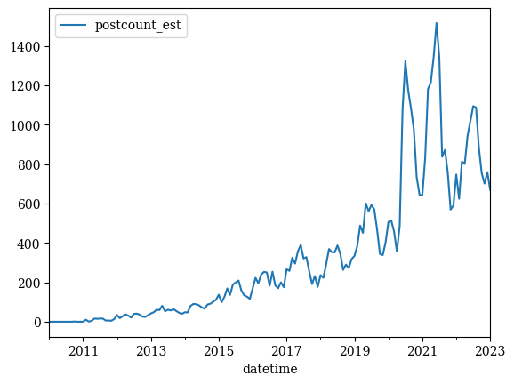

```python
df_post.plot()
```

Repeat for comments:

```python
df = pd.read_csv(REDDIT_ALL_COMMENTS)
df.tail()
```

|  | year | month | post_hll | user_hll | referenced_post_hll | topic_group |
| --- | --- | --- | --- | --- | --- | --- |
| 2215 | 2023 | 4 | \x138b4013231921210225e129c13f2340a14be174c47e... | \x138b4001a269019c61d041 | \x138b4013c116218a01a721b8c3 | shenandoah |
| 2216 | 2023 | 4 | \x138b400c8310e113e31be21ea224e12dc12e8137a23c... | \x138b40348143e145a1d841e802e841f5c2 | \x138b40002325c1270138835361eb67f181 | virginislands |
| 2217 | 2023 | 4 | \x148b4000802104200040238000080020042101020280... | \x138b40016101c108210ac40fc2112115c1174119611b... | \x138b40000100430141018204810561064108a209e10c... | yosemite |
| 2218 | 2023 | 4 | \x138b40004101030142028203010362038105c6060106... | \x138b4016c120e42162226122e2276228e5290329212d... | \x138b40016101c5060107440d8113e117822461260326... | zionnationalpark |
| 2219 | 2023 | 4 | \x138b401924 | \x138b40d221 | \x138b4014e2 | zionnp |

```python
%%time
df_comments = read_csv_datetime(REDDIT_ALL_COMMENTS)
```

```
CPU times: user 16.8 ms, sys: 2.28 ms, total: 19.1 ms
Wall time: 18.1 ms
```

```python
df_comments.head()
```

| datetime | post_hll | user_hll | referenced_post_hll | topic_group |
| --- | --- | --- | --- | --- |
| 2011-02-01 | \x138b4005222b8151c15a226ce379a187038f8297c1b1... | \x138b40182148617501c303dee1 | \x138b40014247c185618c83efc2 | yosemite |
| 2011-03-01 | \x138b40cce2 | \x138b405e44 | \x138b409481 | yosemite |
| 2011-04-01 | \x138b4006218b618ee1b641f061f201f241 | \x138b4076a197a1c303 | \x138b4020c17be294a3 | yosemite |
| 2011-05-01 | \x138b401c812b822d429fc5aa82ca61 | \x138b401ac25e44dee1 | \x138b4012c19cc49e41 | yosemite |
| 2011-06-01 | \x138b402ee1 | \x138b4036c3 | \x138b401181 | hotsprings |

```python
df_comments = append_cardinality_df(df_comments, 'post_hll', 'commentscount_est')
df_comments = filter_fill_time(df_comments, 2010, 2023, 'commentscount_est')
```

```python
def plot_lines(
        df_list: List[pd.DataFrame], ylegend: str = "Post count",
        xlegend: str = "Year", title: Optional[str] = None):
    """Plot lines from a list of DataFrames"""

    fig, ax = plt.subplots()
    fig.set_size_inches(15.7, 4.27)
    ylabel = f'{ylegend} (estimate)'
    for df in df_list:
        ax = df.plot(ax=ax)
    tick_loc = mticker.MultipleLocator(12)
    # x axis ticker formatting
    ax.xaxis.set_major_locator(tick_loc)
    ax.yaxis.set_major_formatter(mticker.StrMethodFormatter('{x:,.0f}'))
    ax.tick_params(axis='x', rotation=45, color='grey')
    ax.set(xlabel=xlegend, ylabel=ylegend)
    ax.spines["left"].set_linewidth(0.25)
    ax.spines["bottom"].set_linewidth(0.25)
    ax.spines["top"].set_linewidth(0)
    ax.spines["right"].set_linewidth(0)
    ax.yaxis.set_tick_params(width=0.5)
    # add legend
    h, l = ax.get_legend_handles_labels()
    ax.legend(h, l, frameon=False, loc='best')
    if title:
        ax.set_title(title)
```

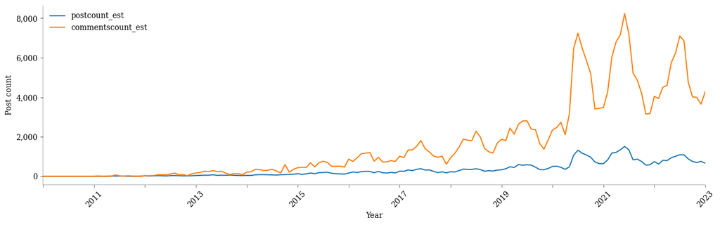

```python
plot_lines([df_post, df_comments])
```

```python
df_comments
```

| datetime | commentscount_est |
| --- | --- |
| 2010-01-31 | 0.0 |
| 2010-02-28 | 0.0 |
| 2010-03-31 | 0.0 |
| 2010-04-30 | 0.0 |
| 2010-05-31 | 0.0 |
| ... | ... |
| 2022-09-30 | 4761.0 |
| 2022-10-31 | 4025.0 |
| 2022-11-30 | 3996.0 |
| 2022-12-31 | 3655.0 |
| 2023-01-31 | 4286.0 |

157 rows × 1 columns

## Group temporal patterns by month

The growth in data contribution on Reddit distorts the curve and limits our ability to view temporal characteristic and repeating patterns. Below, we group data by month, to visualize average and repeating seasonal trends.

```python
def plot_bars(
        df1: pd.DataFrame, df2: pd.DataFrame, ax: matplotlib.axes = None, title: str = None):
    """Plot bars from two DataFrames"""
    colors = sns.color_palette("vlag", as_cmap=True, n_colors=2)
    bar_param = {
        "width":1.0,
        "label":"Reddit total submission count aggregated for months",
        "edgecolor":"white",
        "linewidth":0.5,
        "alpha":0.7
    }
    # create figure
    if not ax:
        fig, ax = plt.subplots(1, 1, figsize=(3, 1.5))
    # plot
    df1.groupby(df1.index.month)["commentscount_est"] \
        .mean().plot.bar(ax=ax, color=colors([1.0]), y="commentscount_est", **bar_param)
    df2.groupby(df2.index.month)["postcount_est"] \
        .mean().plot.bar(ax=ax, color=colors([0.0]), y="postcount_est", **bar_param)
    # format
    ax.set_xlim(-0.5,11.5)
    month_names = ['Jan','Feb','Mar','Apr','May','Jun',
                   'Jul','Aug','Sep','Oct','Nov','Dec']
    ax.set_xticklabels(month_names)
    ax.tick_params(axis='x', rotation=45, length=0) # length: of ticks
    ax.spines["left"].set_linewidth(0.25)
    ax.spines["bottom"].set_linewidth(0.25)
    ax.spines["top"].set_linewidth(0)
    ax.spines["right"].set_linewidth(0)
    ax.yaxis.set_tick_params(width=0.5)
    ax.set(xlabel="", ylabel="")
    if not title:
        title = "Post Count per Month (mean)"
    ax.set_title(title, y=-0.2, pad=-14)
    for item in (
        [ax.xaxis.label, ax.title, ax.yaxis.label] +
         ax.get_xticklabels() + ax.get_yticklabels()):
            item.set_fontsize(8)
```

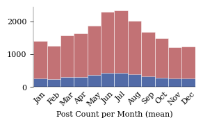

```python
plot_bars(df1=df_comments, df2=df_post)
```

Visualize for all Nationalparks separately.

```python
national_parks = df['topic_group'].unique()
print(len(national_parks))
```

```
46
```

Get summary of total posts per Nationalpark, for sorting:

```python
def replace_datetime_with_month(df: pd.DataFrame):
    """Extract month from datetime index, set as new composite index
    together with topic_group"""
    df.set_index([df.index.month, "topic_group"], inplace=True)
    df.index.rename(("month", "topic_group"), inplace=True)
```

```python
df_post = read_csv_datetime(REDDIT_ALL_SUBMISSIONS)
df_comments = read_csv_datetime(REDDIT_ALL_COMMENTS)
df = pd.concat([df_post, df_comments])
replace_datetime_with_month(df)
cardinality_series = tools.union_hll_series(
    hll_series=df["user_hll"],
    db_conn=db_conn, multiindex=True)
df = cardinality_series.to_frame()
df.rename(columns={"hll_cardinality":"user_count"}, inplace=True)
national_parks_sorted = df.unstack(level=1).fillna(0).droplevel(0, axis=1).sum().sort_values(ascending=False)
```

Preview ranking order

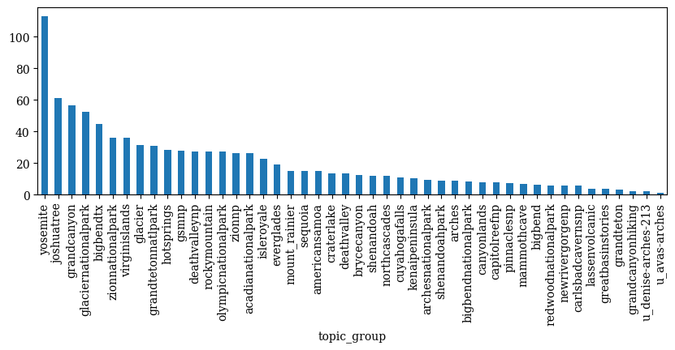

```python
national_parks_sorted.pow(1./2).plot.bar(figsize=(10, 3))
```

We can limit our analysis to the top 50%, as below there is not enough data available.

```python
top_50_cnt = int(len(national_parks_sorted)/2)
top_50 = list(national_parks_sorted.keys())[:top_50_cnt]
```

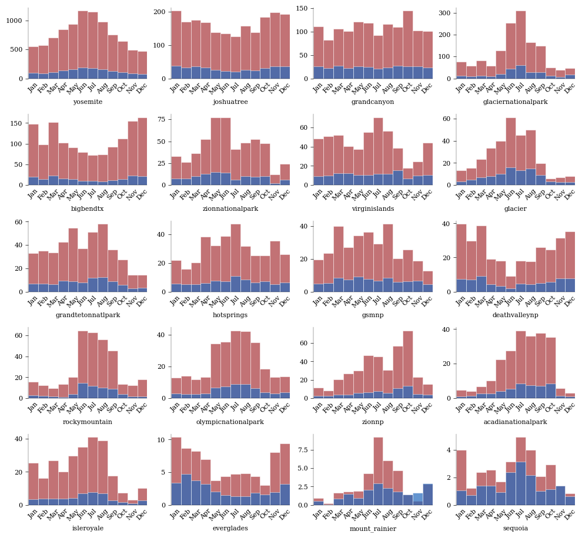

```python
df_comments = read_csv_datetime(REDDIT_ALL_COMMENTS)
df_post = read_csv_datetime(REDDIT_ALL_SUBMISSIONS)
# create figure object with multiple subplots
fig, axes = plt.subplots(nrows=int(top_50_cnt/4), ncols=4, figsize=(12, 11))
fig.subplots_adjust(hspace=.5) # adjust vertical space, to allow title below plot
# iterate nationalparks
for ix, ax in enumerate(axes.reshape(-1)):
    np_str = top_50[ix]
    # filter np_str and calculate cardinality
    df_comments_filter = df_comments[df_comments["topic_group"]==np_str].copy()
    df_comments_filter = append_cardinality_df(df_comments_filter, 'post_hll', 'commentscount_est')
    df_comments_filter = filter_fill_time(df_comments_filter, 2010, 2023, 'commentscount_est')
    df_post_filter = df_post[df_post["topic_group"]==np_str].copy()
    df_post_filter = append_cardinality_df(df_post_filter, 'post_hll', 'postcount_est')
    df_post_filter = filter_fill_time(df_post_filter, 2010, 2023, 'postcount_est')
    # plot bars individually
    plot_bars(
        df1=df_comments_filter,
        df2=df_post_filter, title=np_str, ax=ax)
```

```python
tools.save_fig(fig, output=OUTPUT, name="barplot_nationalparks")
```

### Visualize using joyplot

Import [Joypy](https://github.com/leotac/joypy). Install to `worker_env`, if not available.

```python
avail = True
try:
    import joypy
except:
    avail = False
```

```python
!if [ "$avail" = False ] ; then /opt/conda/envs/worker_env/bin/python -m pip install joypy >&- 2>&-; fi
import joypy
```

First, merge comments+post count into one column, per Nationalpark/month.

```python
df_comments = read_csv_datetime(REDDIT_ALL_COMMENTS)
df_post = read_csv_datetime(REDDIT_ALL_SUBMISSIONS)
```

```python
df_comments.head()
```

| datetime | post_hll | user_hll | referenced_post_hll | topic_group |
| --- | --- | --- | --- | --- |
| 2011-02-01 | \x138b4005222b8151c15a226ce379a187038f8297c1b1... | \x138b40182148617501c303dee1 | \x138b40014247c185618c83efc2 | yosemite |
| 2011-03-01 | \x138b40cce2 | \x138b405e44 | \x138b409481 | yosemite |
| 2011-04-01 | \x138b4006218b618ee1b641f061f201f241 | \x138b4076a197a1c303 | \x138b4020c17be294a3 | yosemite |
| 2011-05-01 | \x138b401c812b822d429fc5aa82ca61 | \x138b401ac25e44dee1 | \x138b4012c19cc49e41 | yosemite |
| 2011-06-01 | \x138b402ee1 | \x138b4036c3 | \x138b401181 | hotsprings |

Data cleanup: There were some topic_group references included that start with `u_` (user-topic_groups). Drop these.

```python
df_comments = df_comments[~df_comments.topic_group.str.startswith('u_')]
```

Update Index to include `topic_group` in composite index

```python
for df in [df_post, df_comments]:
    replace_datetime_with_month(df)
```

Union HLL sets (`user_hll)`

Concat two pd.Series

```python
df = pd.concat([df_post["user_hll"], df_comments["user_hll"]])
```

Now we have a series with duplicate indexes. These need to be unioned with HLL. This will also remove duplicate users appearing in both comments and posts for a given month/National Park.

```python
%%time
cardinality_series = tools.union_hll_series(
    hll_series=df,
    db_conn=db_conn, multiindex=True)
```

```
CPU times: user 25.6 ms, sys: 6.41 ms, total: 32 ms
Wall time: 59.7 ms
```

```python
df = cardinality_series.to_frame()
df.rename(columns={"hll_cardinality":"user_count"}, inplace=True)
```

```python
df.head()
```

| month | topic_group | user_count |
| --- | --- | --- |
| 1 | acadianationalpark | 19 |
|  | americansamoa | 23 |
|  | arches | 4 |
|  | archesnationalpark | 5 |
|  | bigbend | 3 |

We can also use `unstack` to turn the multiindex into a matrix

```python
(df.unstack(level=0)  # unstack level 0 -> pivot index labels to columns
    .fillna(0)  # fill NA-values with 0
    .astype(int)  # float to integer
    .droplevel(0, axis=1)  # remove "user_count" multi-level x-column, after unstack
    .style.background_gradient(cmap='Blues', axis=1)) # colorize
```

| month topic_group | 1 | 2 | 3 | 4 | 5 | 6 | 7 | 8 | 9 | 10 | 11 | 12 |
| --- | --- | --- | --- | --- | --- | --- | --- | --- | --- | --- | --- | --- |
| acadianationalpark | 19 | 40 | 36 | 49 | 52 | 77 | 93 | 86 | 93 | 97 | 23 | 15 |
| americansamoa | 23 | 27 | 23 | 23 | 15 | 9 | 12 | 14 | 17 | 14 | 22 | 20 |
| arches | 4 | 6 | 6 | 6 | 5 | 6 | 4 | 9 | 7 | 8 | 9 | 4 |
| archesnationalpark | 5 | 6 | 9 | 11 | 13 | 7 | 8 | 10 | 8 | 4 | 6 | 3 |
| bigbend | 3 | 2 | 5 | 3 | 3 | 3 | 1 | 0 | 4 | 7 | 2 | 4 |
| bigbendnationalpark | 15 | 8 | 6 | 10 | 5 | 2 | 3 | 1 | 1 | 5 | 4 | 6 |
| bigbendtx | 233 | 192 | 276 | 170 | 124 | 98 | 92 | 103 | 126 | 153 | 232 | 210 |
| brycecanyon | 14 | 13 | 13 | 15 | 14 | 14 | 13 | 13 | 10 | 16 | 8 | 8 |
| canyonlands | 5 | 2 | 9 | 8 | 7 | 4 | 4 | 5 | 4 | 5 | 5 | 6 |
| capitolreefnp | 6 | 3 | 7 | 8 | 5 | 2 | 7 | 4 | 7 | 6 | 2 | 6 |
| carlsbadcavernsnp | 1 | 1 | 5 | 8 | 5 | 3 | 1 | 2 | 0 | 0 | 3 | 2 |
| craterlake | 9 | 7 | 10 | 13 | 19 | 18 | 25 | 36 | 18 | 19 | 6 | 6 |
| cuyahogafalls | 9 | 10 | 9 | 9 | 8 | 9 | 12 | 9 | 10 | 12 | 11 | 8 |
| deathvalley | 22 | 15 | 28 | 18 | 10 | 9 | 15 | 9 | 11 | 13 | 10 | 14 |
| deathvalleynp | 88 | 90 | 125 | 58 | 36 | 23 | 37 | 46 | 43 | 56 | 65 | 87 |
| everglades | 40 | 44 | 48 | 41 | 22 | 20 | 16 | 18 | 23 | 24 | 25 | 33 |
| glacier | 46 | 56 | 69 | 82 | 103 | 186 | 139 | 149 | 74 | 32 | 29 | 34 |
| glaciernationalpark | 131 | 177 | 228 | 155 | 191 | 398 | 521 | 305 | 243 | 108 | 70 | 213 |
| grandcanyon | 271 | 272 | 346 | 305 | 264 | 271 | 209 | 224 | 247 | 269 | 258 | 261 |
| grandcanyonhiking | 0 | 1 | 1 | 0 | 0 | 0 | 1 | 0 | 0 | 0 | 0 | 2 |
| grandteton | 1 | 0 | 0 | 0 | 0 | 1 | 0 | 0 | 2 | 2 | 3 | 1 |
| grandtetonnatlpark | 68 | 69 | 63 | 92 | 88 | 78 | 128 | 144 | 88 | 56 | 34 | 33 |
| greatbasinstories | 0 | 0 | 0 | 5 | 1 | 3 | 1 | 0 | 0 | 0 | 1 | 1 |
| gsmnp | 43 | 55 | 85 | 75 | 92 | 72 | 72 | 82 | 58 | 64 | 55 | 30 |
| hotsprings | 54 | 59 | 77 | 83 | 75 | 72 | 77 | 65 | 57 | 55 | 57 | 56 |
| isleroyale | 38 | 32 | 52 | 43 | 46 | 62 | 67 | 74 | 39 | 26 | 17 | 24 |
| joshuatree | 390 | 417 | 479 | 397 | 244 | 203 | 197 | 230 | 242 | 272 | 349 | 346 |
| kenaipeninsula | 6 | 8 | 7 | 15 | 9 | 10 | 6 | 11 | 10 | 13 | 6 | 5 |
| lassenvolcanic | 0 | 3 | 2 | 1 | 0 | 1 | 0 | 1 | 2 | 0 | 3 | 1 |
| mammothcave | 1 | 2 | 6 | 5 | 6 | 2 | 10 | 1 | 2 | 4 | 3 | 0 |
| mount_rainier | 9 | 5 | 18 | 28 | 12 | 26 | 35 | 30 | 21 | 13 | 12 | 15 |
| newrivergorgenp | 5 | 1 | 2 | 2 | 2 | 2 | 3 | 6 | 2 | 6 | 0 | 1 |
| northcascades | 5 | 11 | 13 | 15 | 9 | 10 | 28 | 21 | 15 | 6 | 2 | 3 |
| olympicnationalpark | 37 | 44 | 69 | 80 | 63 | 72 | 92 | 81 | 70 | 50 | 39 | 43 |
| pinnaclesnp | 10 | 3 | 6 | 5 | 8 | 4 | 3 | 1 | 3 | 4 | 4 | 3 |
| redwoodnationalpark | 6 | 1 | 1 | 1 | 1 | 6 | 4 | 5 | 2 | 3 | 2 | 0 |
| rockymountain | 39 | 40 | 41 | 56 | 49 | 134 | 119 | 99 | 82 | 43 | 23 | 26 |
| sequoia | 17 | 18 | 22 | 18 | 9 | 20 | 28 | 32 | 16 | 17 | 15 | 8 |
| shenandoah | 12 | 11 | 8 | 11 | 5 | 5 | 9 | 15 | 19 | 35 | 9 | 6 |
| shenandoahpark | 2 | 4 | 7 | 8 | 6 | 5 | 13 | 8 | 7 | 10 | 8 | 2 |
| virginislands | 92 | 117 | 123 | 119 | 128 | 114 | 112 | 103 | 114 | 64 | 98 | 105 |
| yosemite | 778 | 961 | 1131 | 1164 | 1249 | 1550 | 1456 | 1267 | 971 | 849 | 750 | 645 |
| zionnationalpark | 88 | 82 | 180 | 188 | 147 | 131 | 67 | 108 | 118 | 107 | 38 | 57 |
| zionnp | 29 | 23 | 47 | 46 | 54 | 68 | 76 | 59 | 100 | 110 | 47 | 37 |

```python
df_plot = df.unstack(level=1).fillna(0).droplevel(0, axis=1).pow(1./4)
```

Create a sorted dictionary for explicit plotting order in joyplot. Note that as of Python 3.7, dictionaries are guarnteed to be ordered.

```python
d = {}
for np_ref in top_50:
    d[np_ref] = df_plot[np_ref]
```

visualize

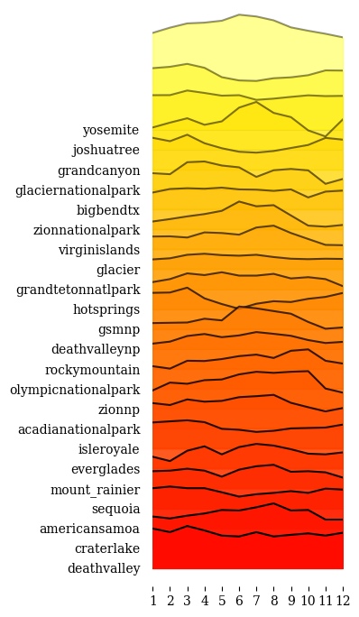

```python
month_num = range(1, 13)
tick_pos = range(0, 12)
fig, ax = joypy.joyplot(
    d, kind="values", x_range=[0, 11], figsize=(4, 7),
    colormap=matplotlib.cm.autumn_r, fade=True, overlap=2, grid="y", legend=True)
ax[-1].set_xticks(tick_pos, labels=month_num)
plt.show()
```

Calculate total averages and "diverge from average" per park/month

```python
df_plot = df.unstack(level=1).fillna(0).droplevel(0, axis=1)
```

```python
averages = df_plot.mean()
```

Create plotting order/selection based on absolute user counts of peak month:

```python
order_np: Dict[str, int] = {}
for ix, park in enumerate(top_50):
    peak_value = max(df_plot[park])
    peak_month = list(df_plot[park]).index(peak_value)
    order_np[park] = df.loc[peak_month, park].user_count
```

```python
top_50_plot = list(pd.Series(order_np).sort_values(ascending=False).keys())
```

Apply a number of modifications, to optimize visual legibility:

- visualize diverge from mean, not absolute values
- stretch these values to 1-100 range
- reduce 1-100 range height, beginning with less visited parks (will prevent overlap)
- order of plots is based on sorting of user visitations average in peak months

```python
a = 1 # min
b = 100 # max'
for ix, park in enumerate(top_50_plot):
    perc = ix/(len(top_50)/100)
    b_mod = abs(perc-b)
    x = df_plot[park]
    df_plot[park] = a + (x - x.min()) * (b_mod - a) / (x.max() - x.min())
```

Create dictionary for plotting order:

```python
d = {}
for np_ref in top_50_plot:
    d[np_ref] = df_plot[np_ref]
```

For annotating peaks, to avoid collision, we manually define text offset ahead of time.

```python
xy_txt = {
    'yosemite':(20, 10),
    'joshuatree':(-70, 2),
    'grandcanyon':(5, 2),
    'glaciernationalpark':(5, 2),
    'bigbendtx':(-70, 2),
    'zionnationalpark':(2, 5),
    'virginislands':(-70, -20),
    'glacier':(5, 2),
    'grandtetonnatlpark':(5, 5),
    'hotsprings':(-70, -20),
    'gsmnp':(15, 2),
    'deathvalleynp':(5, 2),
    'rockymountain':(-80, -20),
    'olympicnationalpark':(5, 5),
    'zionnp':(5, 2),
    'acadianationalpark':(-30, -30),
    'isleroyale':(10, -10),
    'everglades':(-50, 2),
    'mount_rainier':(-50, 10),
    'sequoia':(5, 10),
    'craterlake':(5, 10),
    'americansamoa':(5, 10),
    'deathvalley':(5, 2),
}
```

Create plot

[figure not shown]

```python
from adjustText import adjust_text
month_num = range(1, 13)
tick_pos = range(0, 12)
fig, ax = joypy.joyplot(
    d, kind="values", x_range=[0, 11], figsize=(8, 6),
    colormap=matplotlib.cm.autumn_r, fade=True, overlap=2, grid="y", legend=True)
ax[-1].set_xticks(tick_pos, labels=month_num)
for ix, park in enumerate(top_50_plot):
    peak_value = max(df_plot[park])
    peak_month = list(df_plot[park]).index(peak_value)
    ax[ix].plot(peak_month, peak_value, marker='o', markerfacecolor='black', markeredgecolor="white", zorder=1000, markersize=5)
    xy_pos = xy_txt.get(park)
    ax[ix].annotate(
        f"r/{park}\n{calendar.month_name[peak_month][:3]}, {df.loc[peak_month, park].user_count} user",
        xy=(peak_month, peak_value), xytext=xy_pos, zorder=1001,
        fontsize='medium', textcoords='offset points',
        path_effects=[pe.withStroke(linewidth=2, foreground="white")],
        arrowprops=dict(
            arrowstyle="-",
            color='black', lw=0.5, alpha=0.8, mutation_scale=4,
            connectionstyle=f'arc3,rad=-0.3')
    )
fig.show()
```

save as svg and png

```python
tools.save_fig(fig, output=OUTPUT, name="joyplot_nationalparks")
```

We want to compare temporal patterns for different parks. For instance, some parks may be particularly interesting during Spring (e.g. Yosemite, for Waterfalls being most impressive; or Shanandoah National Park, for colorfull autumn foliage).

```python
#TODO
```

# Create notebook HTML

```python
!jupyter nbconvert --to html_toc \
    --output-dir=../resources/html/ ./02_reddit_nationalparks.ipynb \
    --template=../nbconvert.tpl \
    --ExtractOutputPreprocessor.enabled=False >&- 2>&-
```